# Project 2 - Pandas & Visualization 101

- Your Name Here: Xiaoya Luo
- WFU Email Address: luox23@wfu.edu
- Submission Date: 7/23/2023

# Instructions

1. Download the notebook `pandas_viz_101_yournamehere.ipynb` and the dataset `AmazonReviews.json` from the course website.
2. Open the notebook on your local computer; Or upload and open it in Google Colab.
3. Replace the placeholder text above with your name, email address, and submission date.
4. This is a simple project made up of mini-tasks. Simply write the code to answer the question, and be sure to display your results!
5. Please submit your notebook in **HTML** on Canvas.

# Amazon Reviews

The `AmazonReviews.json` dataset contains over 370,000 reviews of products in Beauty and Personal Care. The data was initially scraped, munged and prepped by Jianno Ni (https://nijianmo.github.io/) an NLP researcher/engineer at Google.

Your challenge is to further prepare the data (easy), create summaries and charts answering various questions about the data (also easy). To complete this project, please follow these steps:

## Step 0. Load Libraries

Load the following libraries, you may need to install them first.

- Data Manipulation: `pandas`, `numpy`
- Data Visualization：`seaborn`, `matplotlib.pyplot`

```python
import pandas as pd
import numpy as np
import matplotlib.pyplot as plt
import seaborn as sns
%matplotlib inline
import warnings
warnings.filterwarnings("ignore") # suppress the FutureWarning
```

## Step 1. Stage

1. Use `pd.read_json()` from `pandas` to read in `AmazonReviews.json` data file, store it as a new data frame called `"df_review"`
2. Display the first 7 records
3. Check the shape and data types using `info()`

```python
df_review = pd.read_json('/content/AmazonReviews.json')
```

```python
df_review.head(7)
```

|  | reviewerID | reviewerName | reviewTime | itemID | reviewText | overallRating | summary | verified |
| --- | --- | --- | --- | --- | --- | --- | --- | --- |
| 0 | A1V6B6TNIC10QE | theodore j bigham | 02 19, 2015 | 0143026860 | great | 1 | One Star | True |
| 1 | A2F5GHSXFQ0W6J | Mary K. Byke | 12 18, 2014 | 0143026860 | My husband wanted to reading about the Negro ... | 4 | ... to reading about the Negro Baseball and th... | True |
| 2 | A1572GUYS7DGSR | David G | 08 10, 2014 | 0143026860 | This book was very informative, covering all a... | 4 | Worth the Read | True |
| 3 | A1PSGLFK1NSVO | TamB | 03 11, 2013 | 0143026860 | I am already a baseball fan and knew a bit abo... | 5 | Good Read | True |
| 4 | A6IKXKZMTKGSC | shoecanary | 12 25, 2011 | 0143026860 | This was a good story of the Black leagues. I ... | 5 | More than facts, a good story read! | True |
| 5 | A36NF437WZLQ9E | W. Powell | 02 26, 2010 | 0143026860 | Today I gave a book about the Negro Leagues of... | 5 | The Gift of Black Baseball | False |
| 6 | A10Q8NIFOVOHFV | Robert S. Clay Jr. | 03 7, 2001 | 0143026860 | The story of race relations in American histor... | 4 | Baseball, America, and racism. | False |

```python
df_review.info()
```

```
<class 'pandas.core.frame.DataFrame'>
RangeIndex: 371345 entries, 0 to 371344
Data columns (total 8 columns):
 #   Column         Non-Null Count   Dtype
---  ------         --------------   -----
 0   reviewerID     371345 non-null  object
 1   reviewerName   371307 non-null  object
 2   reviewTime     371345 non-null  object
 3   itemID         371345 non-null  object
 4   reviewText     370946 non-null  object
 5   overallRating  371345 non-null  int64
 6   summary        371139 non-null  object
 7   verified       371345 non-null  bool
dtypes: bool(1), int64(1), object(6)
memory usage: 20.2+ MB
```

## Step 2. Structure & Transform (Part I)

Applying data cleaning methods to the dataset `df_review`:

1. Summarize NAs: Report the **number** and **percentage** of missing values for each column
2. Clean NAs: Drop any rows where `reviewText` is None
3. Drop the columns of `summary` and `reviewerName`
4. Double-check NAs: Given the processed data, double check the **number** and **percentage** of missing values for each column

   > Hint: There sholud be no NAs anymore
5. Explore the column of `verified`, report the percentage of rows that are verified using `value_counts()`
6. Filter and keep the subset of data where`verified==True`. Store this as a new data frame `df_review_prep`

   > Hint: There should be 322098 rows

```python
# Summarize NAs: Report the number and percentage of missing values for each column
print(df_review.isna().sum())
print(df_review.isna().sum()/df_review.shape[0])
```

```
reviewerID         0
reviewerName      38
reviewTime         0
itemID             0
reviewText       399
overallRating      0
summary          206
verified           0
dtype: int64
reviewerID       0.000000
reviewerName     0.000102
reviewTime       0.000000
itemID           0.000000
reviewText       0.001074
overallRating    0.000000
summary          0.000555
verified         0.000000
dtype: float64
```

```python
# Clean NAs: Drop any rows where reviewText is None
df_review = df_review.dropna(subset=['reviewText'])
df_review
```

|  | reviewerID | reviewerName | reviewTime | itemID | reviewText | overallRating | summary | verified |
| --- | --- | --- | --- | --- | --- | --- | --- | --- |
| 0 | A1V6B6TNIC10QE | theodore j bigham | 02 19, 2015 | 0143026860 | great | 1 | One Star | True |
| 1 | A2F5GHSXFQ0W6J | Mary K. Byke | 12 18, 2014 | 0143026860 | My husband wanted to reading about the Negro ... | 4 | ... to reading about the Negro Baseball and th... | True |
| 2 | A1572GUYS7DGSR | David G | 08 10, 2014 | 0143026860 | This book was very informative, covering all a... | 4 | Worth the Read | True |
| 3 | A1PSGLFK1NSVO | TamB | 03 11, 2013 | 0143026860 | I am already a baseball fan and knew a bit abo... | 5 | Good Read | True |
| 4 | A6IKXKZMTKGSC | shoecanary | 12 25, 2011 | 0143026860 | This was a good story of the Black leagues. I ... | 5 | More than facts, a good story read! | True |
| ... | ... | ... | ... | ... | ... | ... | ... | ... |
| 371340 | A202DCI7TV1022 | Sam | 07 20, 2017 | B01HJEGTYK | It was awful. It was super frizzy and I tried ... | 1 | It was super frizzy and I tried to comb it and... | True |
| 371341 | A3FSOR5IJOFIBE | TYW | 03 16, 2017 | B01HJEGTYK | I was skeptical about buying this. Worried it... | 5 | Awesome | True |
| 371342 | A1B5DK6CTP2P24 | Norma Jennings | 03 1, 2017 | B01HJEGTYK | Makes me look good fast. | 5 | Five Stars | True |
| 371343 | A23OUYS5IRMJS9 | Lee | 02 21, 2017 | B01HJEGTYK | Way lighter than photo\nNot mix blend of color... | 2 | Ok but color way off and volume as well | True |
| 371344 | A24KQ9RVU81L87 | Season341 | 12 15, 2016 | B01HJEGTYK | No return instructions/phone # in packaging. ... | 2 | Might return for a replacement if I could. | True |

370946 rows × 8 columns

```python
# Drop the columns of summary and reviewerName
df_review = df_review.drop(columns = ['summary','reviewerName'])
df_review
```

|  | reviewerID | reviewTime | itemID | reviewText | overallRating | verified |
| --- | --- | --- | --- | --- | --- | --- |
| 0 | A1V6B6TNIC10QE | 02 19, 2015 | 0143026860 | great | 1 | True |
| 1 | A2F5GHSXFQ0W6J | 12 18, 2014 | 0143026860 | My husband wanted to reading about the Negro ... | 4 | True |
| 2 | A1572GUYS7DGSR | 08 10, 2014 | 0143026860 | This book was very informative, covering all a... | 4 | True |
| 3 | A1PSGLFK1NSVO | 03 11, 2013 | 0143026860 | I am already a baseball fan and knew a bit abo... | 5 | True |
| 4 | A6IKXKZMTKGSC | 12 25, 2011 | 0143026860 | This was a good story of the Black leagues. I ... | 5 | True |
| ... | ... | ... | ... | ... | ... | ... |
| 371340 | A202DCI7TV1022 | 07 20, 2017 | B01HJEGTYK | It was awful. It was super frizzy and I tried ... | 1 | True |
| 371341 | A3FSOR5IJOFIBE | 03 16, 2017 | B01HJEGTYK | I was skeptical about buying this. Worried it... | 5 | True |
| 371342 | A1B5DK6CTP2P24 | 03 1, 2017 | B01HJEGTYK | Makes me look good fast. | 5 | True |
| 371343 | A23OUYS5IRMJS9 | 02 21, 2017 | B01HJEGTYK | Way lighter than photo\nNot mix blend of color... | 2 | True |
| 371344 | A24KQ9RVU81L87 | 12 15, 2016 | B01HJEGTYK | No return instructions/phone # in packaging. ... | 2 | True |

370946 rows × 6 columns

```python
# Double-check NAs: Given the processed data, double check the number and percentage of missing values for each column
print(df_review.isna().sum())
print(df_review.isna().sum()/df_review.shape[0])
```

```
reviewerID       0
reviewTime       0
itemID           0
reviewText       0
overallRating    0
verified         0
dtype: int64
reviewerID       0.0
reviewTime       0.0
itemID           0.0
reviewText       0.0
overallRating    0.0
verified         0.0
dtype: float64
```

```python
# Explore the column of verified, report the percentage of rows that are verified using value_counts()
value_counts_reviews = df_review['verified'].value_counts(normalize=True)
value_counts_reviews
# df_review['verified'].value_counts(normailze = True)
```

```
True     0.868315
False    0.131685
Name: verified, dtype: float64
```

```python
# Filter and keep the subset of data whereverified==True. Store this as a new data frame df_review_prep
# Hint: There should be 322098 rows
df_review_prep = df_review[df_review['verified']==True]
df_review_prep
```

|  | reviewerID | reviewTime | itemID | reviewText | overallRating | verified |
| --- | --- | --- | --- | --- | --- | --- |
| 0 | A1V6B6TNIC10QE | 02 19, 2015 | 0143026860 | great | 1 | True |
| 1 | A2F5GHSXFQ0W6J | 12 18, 2014 | 0143026860 | My husband wanted to reading about the Negro ... | 4 | True |
| 2 | A1572GUYS7DGSR | 08 10, 2014 | 0143026860 | This book was very informative, covering all a... | 4 | True |
| 3 | A1PSGLFK1NSVO | 03 11, 2013 | 0143026860 | I am already a baseball fan and knew a bit abo... | 5 | True |
| 4 | A6IKXKZMTKGSC | 12 25, 2011 | 0143026860 | This was a good story of the Black leagues. I ... | 5 | True |
| ... | ... | ... | ... | ... | ... | ... |
| 371340 | A202DCI7TV1022 | 07 20, 2017 | B01HJEGTYK | It was awful. It was super frizzy and I tried ... | 1 | True |
| 371341 | A3FSOR5IJOFIBE | 03 16, 2017 | B01HJEGTYK | I was skeptical about buying this. Worried it... | 5 | True |
| 371342 | A1B5DK6CTP2P24 | 03 1, 2017 | B01HJEGTYK | Makes me look good fast. | 5 | True |
| 371343 | A23OUYS5IRMJS9 | 02 21, 2017 | B01HJEGTYK | Way lighter than photo\nNot mix blend of color... | 2 | True |
| 371344 | A24KQ9RVU81L87 | 12 15, 2016 | B01HJEGTYK | No return instructions/phone # in packaging. ... | 2 | True |

322098 rows × 6 columns

```python
df_review_prep.shape
```

```
(322098, 6)
```

## Step 3. Structure & Transform (Part II)

Given the data frame `"df_review_prep"` we created, please further transform the data by performing the following:

1. Create binary indicators (aka flag variables or dummy variables)
- Create a flag variable "good_flag" if the `reviewText` mentions the word "good", regardless of case, set the flag to 1 else default it to 0

  > There should be around 43831 references to “good”.
- Create a flag variable "great_flag" if the `reviewText` mentions the word "great", regardless of case, set the flag to 1 else default it to 0

  > There should be around 62080 references to “great”.
- Create a flag variable "bad_flag", if the `reviewText` mentions the word "bad", regardless of case, set the flag to 1 else default it to 0

  > There should be around 6710 references to “bad”.

> One approach to create flag variables (there are many):

> ```
> df['good_flag'] = 0
> df['good_flag'][df['text'].str.contains('good', case=False)] = 1
> ```

1. Create another variable "review_len" which is the number of characters each review includes

   > Hint:

   > ```
   > df['text_len'] = df['text'].str.len()
   > ```

2. List the first 5 records of `"df_review_prep"` to make sure your code works

```python
# Create binary indicators (aka flag variables or dummy variables)
# Create a flag variable "good_flag" if the reviewText mentions the word "good", regardless of case, set the flag to 1 else default it to 0
# There should be around 43831 references to “good”.
df_review_prep['good_flag'] = 0
df_review_prep['good_flag'][df_review_prep['reviewText'].str.contains('good',case=False)] = 1
df_review_prep['good_flag'].value_counts()
```

```
0    278267
1     43831
Name: good_flag, dtype: int64
```

```python
# Create a flag variable "great_flag" if the reviewText mentions the word "great", regardless of case, set the flag to 1 else default it to 0
# There should be around 62080 references to “great”.

df_review_prep['great_flag'] = 0
df_review_prep['great_flag'][df_review_prep['reviewText'].str.contains('great',case=False)] = 1
df_review_prep['great_flag'].value_counts()
```

```
0    260018
1     62080
Name: great_flag, dtype: int64
```

```python
# Create a flag variable "bad_flag", if the reviewText mentions the word "bad", regardless of case, set the flag to 1 else default it to 0
# There should be around 6710 references to “bad”.
df_review_prep['bad_flag'] = 0
df_review_prep['bad_flag'][df_review_prep['reviewText'].str.contains('bad',case=False)] = 1
df_review_prep['bad_flag'].value_counts()
```

```
0    315388
1      6710
Name: bad_flag, dtype: int64
```

```python
# Create another variable "review_len" which is the number of characters each review includes
df_review_prep['review_len'] = df_review_prep['reviewText'].str.len()
df_review_prep.head()
```

|  | reviewerID | reviewTime | itemID | reviewText | overallRating | verified | good_flag | great_flag | bad_flag | review_len |
| --- | --- | --- | --- | --- | --- | --- | --- | --- | --- | --- |
| 0 | A1V6B6TNIC10QE | 02 19, 2015 | 0143026860 | great | 1 | True | 0 | 1 | 0 | 5 |
| 1 | A2F5GHSXFQ0W6J | 12 18, 2014 | 0143026860 | My husband wanted to reading about the Negro ... | 4 | True | 0 | 1 | 0 | 170 |
| 2 | A1572GUYS7DGSR | 08 10, 2014 | 0143026860 | This book was very informative, covering all a... | 4 | True | 0 | 0 | 0 | 61 |
| 3 | A1PSGLFK1NSVO | 03 11, 2013 | 0143026860 | I am already a baseball fan and knew a bit abo... | 5 | True | 0 | 0 | 0 | 111 |
| 4 | A6IKXKZMTKGSC | 12 25, 2011 | 0143026860 | This was a good story of the Black leagues. I ... | 5 | True | 1 | 0 | 0 | 366 |

## Step 4. Frequency Analysis & Graphs

1. Create 4 basic bar charts using `sns.countplot()` to explore `overallRating` - set the argument `hue` (i.e., color setting) by indicated fields respectively: `None`, `good_flag`, `great_flag`, `bad_flag`.

> Hint: Expected charts can be created using code like this

> ```
> plt.figure(figsize=(6, 4))
> factor = 'your_flag_variable'
> sns.countplot(data=df, x="your_main_variable", hue=factor).set_title('your title')
> plt.xlabel('your x label')
> plt.ylabel('your y label')
> plt.show()
> ```

1. To further explore `overallRating`, let's create stacked bar charts that present data as percentages. This method is particularly effective for comparing the proportion each subgroup contributes to the total.

   In a 100% stacked bar chart, each bar will represent a unique rating value (1-5 stars) under `overallRating`. The segments of each bar will illustrate the percentage of reviews at that specific rating that have been flagged as either 'good', 'great', or 'bad'.

   Let's create **three** 100% stacked bar charts - each one visualizes the relationship between `overallRating` and one of the binary flag variables respectively (`good_flag`, `great_flag`, `bad_flag`).

   **Describe** the insights or patterns you find.

> Hint: Expected charts can be created using code like this

> ```
> main_category = 'your_main_variable'
> binary_category = 'your_flag_variable'
> df_grouped = df.groupby(main_category)[binary_category].value_counts(normalize=True).unstack()
> df_grouped.plot(kind='bar', stacked=True, figsize=(6,3))
> plt.ylabel('Percentage')
> plt.show()
> ```

Create 4 basic bar charts using sns.countplot() to explore overallRating - set the argument hue (i.e., color setting) by indicated fields respectively: None, good_flag, great_flag, bad_flag

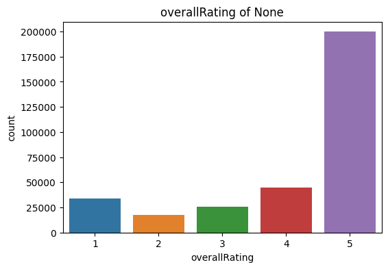

```python
# None
plt.figure(figsize=(6, 4))
factor = None
sns.countplot(data=df_review_prep, x="overallRating", hue=factor).set_title('overallRating of None')
plt.xlabel('overallRating')
plt.ylabel('count')
plt.show()
```

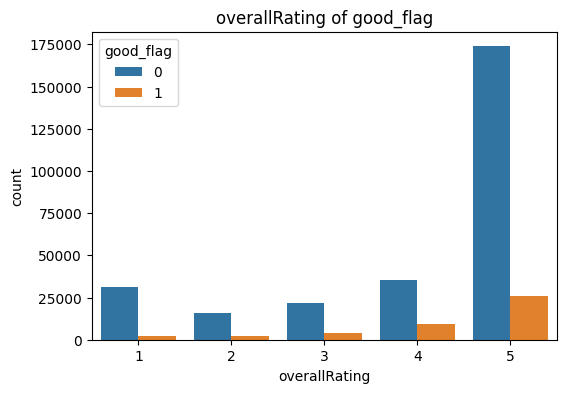

```python
# good_flag
plt.figure(figsize=(6, 4))
factor = 'good_flag'
sns.countplot(data=df_review_prep, x="overallRating", hue=factor).set_title('overallRating of good_flag')
plt.xlabel('overallRating')
plt.ylabel('count')
plt.show()
```

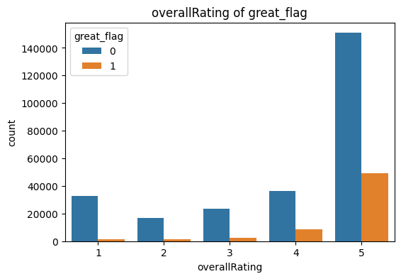

```python
# great_flag
plt.figure(figsize=(6, 4))
factor = 'great_flag'
sns.countplot(data=df_review_prep, x="overallRating", hue=factor).set_title('overallRating of great_flag')
plt.xlabel('overallRating')
plt.ylabel('count')
plt.show()
```

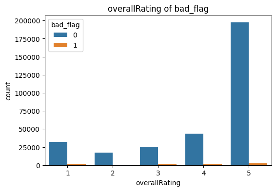

```python
# bad_flag
plt.figure(figsize=(6, 4))
factor = 'bad_flag'
sns.countplot(data=df_review_prep, x="overallRating", hue=factor).set_title('overallRating of bad_flag')
plt.xlabel('overallRating')
plt.ylabel('count')
plt.show()
```

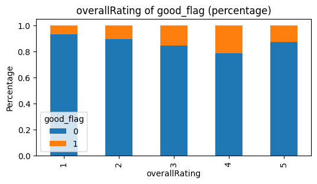

```python
# To further explore overallRating, let's create stacked bar charts that present data as percentages. This method is particularly effective for
# comparing the proportion each subgroup contributes to the total.
# good_flag
main_category = 'overallRating'
binary_category = 'good_flag'
df_grouped = df_review_prep.groupby(main_category)[binary_category].value_counts(normalize=True).unstack()
df_grouped.plot(kind='bar', stacked=True, figsize=(6,3))
plt.title("overallRating of good_flag (percentage)")
plt.ylabel('Percentage')
plt.show()
```

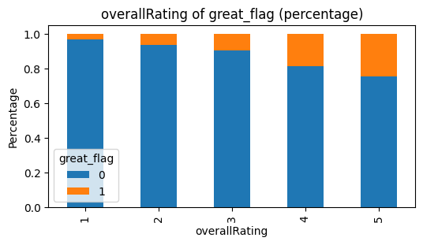

```python
# great_flag
main_category = 'overallRating'
binary_category = 'great_flag'
df_grouped = df_review_prep.groupby(main_category)[binary_category].value_counts(normalize=True).unstack()
df_grouped.plot(kind='bar', stacked=True, figsize=(6,3))
plt.title("overallRating of great_flag (percentage)")
plt.ylabel('Percentage')
plt.show()
```

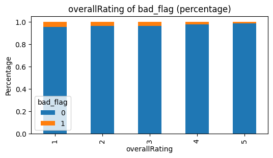

```python
# bad_flag
main_category = 'overallRating'
binary_category = 'bad_flag'
df_grouped = df_review_prep.groupby(main_category)[binary_category].value_counts(normalize=True).unstack()
df_grouped.plot(kind='bar', stacked=True, figsize=(6,3))
plt.title("overallRating of bad_flag (percentage)")
plt.ylabel('Percentage')
plt.show()
```

## Step 5. Does Time Matter?

1. Clean datetimes: Change the data type of `reviewTime` to a standard type `datetime`

   > Hint: Consider using `pd.to_datetime()`
2. Create 4 new variables to store the year, month, day, and day of week by applying transformation to `reviewTime`

   > Hint:

   > ```
   > df['year'] = df['date_variable'].dt.year
   > df['month'] = df['date_variable'].dt.month
   > df['day'] = df['date_variable'].dt.day
   > df['day_of_week'] = df['date_variable'].dt.weekday # where 0 represents Monday
   > ```

3. Group by `day_of_week`, then Report the following summaries in one single data frame named `df_summary`:
   - count the total number of reviews
   - calculate the mean of `overallRating`
   - calculate the mean of `review_len`
1. Create three Bar charts using `sns.barplot()` to answer the following questions:
- What is the most/least reviewed year?
- What year are you most likely to get the highest/lowest mean review length?
- For the data in July 2018, what day of week are you most likely to get the highest/lowest mean overall rating?

```python
# Clean datetimes: Change the data type of reviewTime to a standard type datetime
# Hint: Consider using pd.to_datetime()
df_review_prep['reviewTime']=pd.to_datetime(df_review_prep['reviewTime'])
df_review_prep
```

|  | reviewerID | reviewTime | itemID | reviewText | overallRating | verified | good_flag | great_flag | bad_flag | review_len |
| --- | --- | --- | --- | --- | --- | --- | --- | --- | --- | --- |
| 0 | A1V6B6TNIC10QE | 2015-02-19 | 0143026860 | great | 1 | True | 0 | 1 | 0 | 5 |
| 1 | A2F5GHSXFQ0W6J | 2014-12-18 | 0143026860 | My husband wanted to reading about the Negro ... | 4 | True | 0 | 1 | 0 | 170 |
| 2 | A1572GUYS7DGSR | 2014-08-10 | 0143026860 | This book was very informative, covering all a... | 4 | True | 0 | 0 | 0 | 61 |
| 3 | A1PSGLFK1NSVO | 2013-03-11 | 0143026860 | I am already a baseball fan and knew a bit abo... | 5 | True | 0 | 0 | 0 | 111 |
| 4 | A6IKXKZMTKGSC | 2011-12-25 | 0143026860 | This was a good story of the Black leagues. I ... | 5 | True | 1 | 0 | 0 | 366 |
| ... | ... | ... | ... | ... | ... | ... | ... | ... | ... | ... |
| 371340 | A202DCI7TV1022 | 2017-07-20 | B01HJEGTYK | It was awful. It was super frizzy and I tried ... | 1 | True | 0 | 0 | 0 | 133 |
| 371341 | A3FSOR5IJOFIBE | 2017-03-16 | B01HJEGTYK | I was skeptical about buying this. Worried it... | 5 | True | 0 | 0 | 0 | 246 |
| 371342 | A1B5DK6CTP2P24 | 2017-03-01 | B01HJEGTYK | Makes me look good fast. | 5 | True | 1 | 0 | 0 | 24 |
| 371343 | A23OUYS5IRMJS9 | 2017-02-21 | B01HJEGTYK | Way lighter than photo\nNot mix blend of color... | 2 | True | 0 | 0 | 0 | 142 |
| 371344 | A24KQ9RVU81L87 | 2016-12-15 | B01HJEGTYK | No return instructions/phone # in packaging. ... | 2 | True | 0 | 0 | 0 | 183 |

322098 rows × 10 columns

```python
# Create 4 new variables to store the year, month, day, and day of week by applying transformation to reviewTime
df_review_prep['year'] = df_review_prep['reviewTime'].dt.year
df_review_prep['month'] = df_review_prep['reviewTime'].dt.month
df_review_prep['day'] = df_review_prep['reviewTime'].dt.day
df_review_prep['day_of_week'] = df_review_prep['reviewTime'].dt.weekday  # where 0 represents Monday
df_review_prep
```

|  | reviewerID | reviewTime | itemID | reviewText | overallRating | verified | good_flag | great_flag | bad_flag | review_len | year | month | day | day_of_week |
| --- | --- | --- | --- | --- | --- | --- | --- | --- | --- | --- | --- | --- | --- | --- |
| 0 | A1V6B6TNIC10QE | 2015-02-19 | 0143026860 | great | 1 | True | 0 | 1 | 0 | 5 | 2015 | 2 | 19 | 3 |
| 1 | A2F5GHSXFQ0W6J | 2014-12-18 | 0143026860 | My husband wanted to reading about the Negro ... | 4 | True | 0 | 1 | 0 | 170 | 2014 | 12 | 18 | 3 |
| 2 | A1572GUYS7DGSR | 2014-08-10 | 0143026860 | This book was very informative, covering all a... | 4 | True | 0 | 0 | 0 | 61 | 2014 | 8 | 10 | 6 |
| 3 | A1PSGLFK1NSVO | 2013-03-11 | 0143026860 | I am already a baseball fan and knew a bit abo... | 5 | True | 0 | 0 | 0 | 111 | 2013 | 3 | 11 | 0 |
| 4 | A6IKXKZMTKGSC | 2011-12-25 | 0143026860 | This was a good story of the Black leagues. I ... | 5 | True | 1 | 0 | 0 | 366 | 2011 | 12 | 25 | 6 |
| ... | ... | ... | ... | ... | ... | ... | ... | ... | ... | ... | ... | ... | ... | ... |
| 371340 | A202DCI7TV1022 | 2017-07-20 | B01HJEGTYK | It was awful. It was super frizzy and I tried ... | 1 | True | 0 | 0 | 0 | 133 | 2017 | 7 | 20 | 3 |
| 371341 | A3FSOR5IJOFIBE | 2017-03-16 | B01HJEGTYK | I was skeptical about buying this. Worried it... | 5 | True | 0 | 0 | 0 | 246 | 2017 | 3 | 16 | 3 |
| 371342 | A1B5DK6CTP2P24 | 2017-03-01 | B01HJEGTYK | Makes me look good fast. | 5 | True | 1 | 0 | 0 | 24 | 2017 | 3 | 1 | 2 |
| 371343 | A23OUYS5IRMJS9 | 2017-02-21 | B01HJEGTYK | Way lighter than photo\nNot mix blend of color... | 2 | True | 0 | 0 | 0 | 142 | 2017 | 2 | 21 | 1 |
| 371344 | A24KQ9RVU81L87 | 2016-12-15 | B01HJEGTYK | No return instructions/phone # in packaging. ... | 2 | True | 0 | 0 | 0 | 183 | 2016 | 12 | 15 | 3 |

322098 rows × 14 columns

```python
# Group by day_of_week, then Report the following summaries in one single data frame named df_summary:
# count the total number of reviews
# calculate the mean of overallRating
# calculate the mean of review_len
df_summary = df_review_prep.groupby(['day_of_week']).aggregate({"reviewerID":['count'],"overallRating":['mean'], "review_len":['mean']})
df_summary
```

| day_of_week | reviewerID count | overallRating mean | review_len mean |
| --- | --- | --- | --- |
| 0 | 51281 | 4.109339 | 172.393713 |
| 1 | 49809 | 4.113815 | 169.413881 |
| 2 | 48141 | 4.103758 | 173.003240 |
| 3 | 47575 | 4.124687 | 172.330257 |
| 4 | 44023 | 4.117325 | 174.571042 |
| 5 | 40234 | 4.105980 | 179.238157 |
| 6 | 41035 | 4.123041 | 175.262873 |

```python
df_s1
```

|  | year | reviewCount | reviewLengthMean |
| --- | --- | --- | --- |
| 0 | 2001 | 15 | 598.866667 |
| 1 | 2002 | 15 | 760.000000 |
| 2 | 2003 | 26 | 918.230769 |
| 3 | 2004 | 71 | 782.690141 |
| 4 | 2005 | 150 | 609.833333 |
| 5 | 2006 | 328 | 608.039634 |
| 6 | 2007 | 1233 | 461.610706 |
| 7 | 2008 | 1623 | 430.123845 |
| 8 | 2009 | 2155 | 424.019490 |
| 9 | 2010 | 3951 | 409.714756 |
| 10 | 2011 | 5084 | 405.972266 |
| 11 | 2012 | 7760 | 354.316495 |
| 12 | 2013 | 23081 | 271.107968 |
| 13 | 2014 | 32142 | 187.915002 |
| 14 | 2015 | 62580 | 139.601726 |
| 15 | 2016 | 89636 | 147.162357 |
| 16 | 2017 | 63579 | 136.825902 |
| 17 | 2018 | 28669 | 138.357006 |

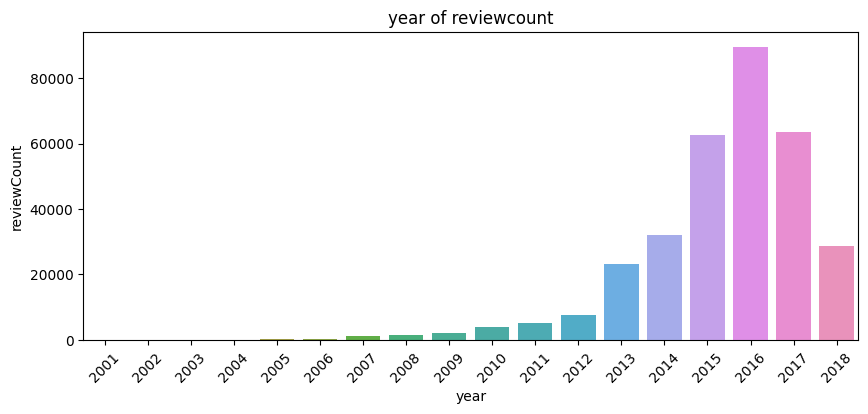

```python
# Create three Bar charts using sns.barplot() to answer the following questions:
# What is the most/least reviewed year?
#df_s1
plt.figure(figsize=(10, 4))
df_s1=df_review_prep.groupby(["year"]).aggregate({"reviewerID":['count'],"review_len":['mean']})
df_s1=df_s1.reset_index()
df_s1.columns=['year','reviewCount','reviewLengthMean']
sns.barplot(data = df_s1, x="year",y="reviewCount")
plt.title("year of reviewcount")
plt.xticks(rotation=45);

# sns.barplot(data=df_review_prep,x="year",y="overallRating",estimator='count',errorbar=None)
```

```python
print("year 2016 is the most reviewed year")
print("year 2001 and 2002 are the least reviewed year")
```

```
year 2016 is the most reviewed year
year 2001 and 2002 are the least reviewed year
```

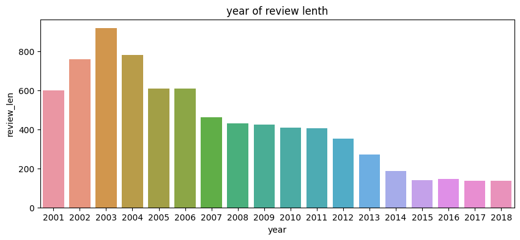

```python
# What year are you most likely to get the highest/lowest mean review length?
plt.figure(figsize=(10, 4))
sns.barplot(data=df_review_prep,x='year',y='review_len',estimator='mean',errorbar=None).set_title('year of review lenth')
plt.show()
```

```python
print("year 2003 is most likelly to get the highest mean review length")
print("year 2017 is most likely to get the lowest mean review length")
```

```
year 2003 is most likelly to get the highest mean review length
year 2017 is most likely to get the lowest mean review length
```

```python
df_s2
```

|  | day_of_week | overallRatingMean |
| --- | --- | --- |
| 0 | 0 | 3.953368 |
| 1 | 1 | 4.080729 |
| 2 | 2 | 3.876712 |
| 3 | 3 | 3.904153 |
| 4 | 4 | 4.032143 |
| 5 | 5 | 4.000000 |
| 6 | 6 | 3.960340 |

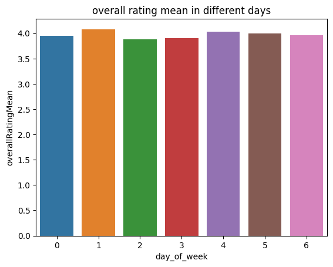

```python
# For the data in July 2018, what day of week are you most likely to get the highest/lowest mean overall rating?
df_s2 = df_review_prep[(df_review_prep['year']==2018)&(df_review_prep['month']==7)].groupby(['day_of_week']).aggregate({"overallRating":['mean']})
df_s2=df_s2.reset_index()
df_s2.columns = ['day_of_week','overallRatingMean']
sns.barplot(data=df_s2,x='day_of_week',y='overallRatingMean');
plt.title("overall rating mean in different days");
```

```python
print("In 2018, Tuesday are most likely to get the highest mean overall rating")
print("In 2018, Wednesday are most likely to get the lowest mean overall rating")
```

```
In 2018, Tuesday are most likely to get the highest mean overall rating
In 2018, Wednesday are most likely to get the lowest mean overall rating
```

## Step 6. Chat with your Data

In this final step, let's build a naive chatbot that can answer simple questions about your data using a **While Loop** and **If-Else Structures**. A good reference to complete this task is [here](https://colab.research.google.com/github/MonkeyWrenchGang/PythonBootcamp/blob/main/day_3/3_4_Journey_into_WHILE_Loops.ipynb). Please follow the instructions and code the missing parts.

- Create a greeting for the user when the chatbot starts, use the `print()` function to display it. For example:

  ```
  print("Hello! I am your friendly chatbot that can answer simple questions about your data.")
  ```

- Use a while loop to start a continuous conversation. The conversation should continue until the user types 'exit'.
- Inside the while loop, use the `input()` function to get the name of a variable from the user, store it as `input_variable`. For example:

  ```
  input_variable = input("What variable would you like to ask me? (Type 'exit' to end the conversation) ")
  ```

- Check if the user's input is a valid column in the data frame `df_review_prep`.
  - If it is, print a message indicating that it's a valid variable and display its data type. For example:

    ```
    print("Good!", input_variable, "is a valid variable in this dataset")
    print('Its data type:', df_review_prep[input_variable].dtypes)
    ```

  - If it isn't, the user should be notified and asked to try again. For example:

    ```
    print('Sorry, your input', input_variable,'is not a variable of the dataset. Please try it again :)')
    ```

- If the user's chosen variable is an integer type 'int64'
  - Use another `input()` to ask what statistic to report. The options should be 'count', 'mean', 'max', 'min', or 'all'. For example:

    ```
    summary_stats = input("What statistic would you like to report? Type one from: [count, mean, max, min, all]")
    ```

  - Depending on the user's input, calculate and display the requested statistic for this variable.
  - If the input isn't recognized, display an error message. For example:

    ```
    print('Please input a valid statistic.')
    ```

- If the user's chosen variable is NOT an integer type 'int64'

  ```
  print('Under development.. Stay tuned :)')
  ```

Example conversation：

```
Hello! I am your friendly chatbot that can answer simple questions about your data.
What variable would you like to ask me? (Type 'exit' to end the conversation) overallRating
Good! overallRating is a valid variable in this dataset
Its data type: int64
What statistic would you like to report? Type one from: [count, mean, max, min, all] all
count    322098.000000
mean          4.113881
std           1.361587
min           1.000000
25%           4.000000
50%           5.000000
75%           5.000000
max           5.000000
Name: overallRating, dtype: float64
What variable would you like to ask me? (Type 'exit' to end the conversation) exit
Goodbye! It was nice chatting with you.
```

```python
# Greet the user
print("Hello! I am your friendly chatbot that can answer simple questions about your data.")

# Start the conversation
while True:
    input_variable = input("What variable would you like to ask me? (Type 'exit' to end the conversation) ")

    # Check if the user wants to exit
    if input_variable.lower() in ["exit","quit"]:
        print("Goodbye! It was nice chatting with you.")
        break

    # Look up response in the dictionary
    if input_variable.lower() in df_review_prep.columns.str.lower():
        print("Good!", input_variable, "is a valid variable in this dataset")
        print('Its data type:', df_review_prep[input_variable].dtypes)
        if df_review_prep[input_variable].dtypes=='int64':
            summary_stats = input("What statistic would you like to report? Type one from: [count, mean, max, min, all]")
            valid=['count', 'mean', 'max', 'min', 'all']
            if (summary_stats.lower() in valid) &(summary_stats.lower()!='all'):
                print(df_review_prep[input_variable].aggregate(func=[summary_stats]))

            elif (summary_stats.lower() in valid) &(summary_stats.lower()=='all'):
                print(df_review_prep[input_variable].describe())

            else:
                print('Please input a valid statistic.')
        else:
            print('Under development.. Stay tuned :)')
    else:
        print('Sorry, your input', input_variable,'is not a variable of the dataset. Please try it again :)')

# End of the program
```

```
Hello! I am your friendly chatbot that can answer simple questions about your data.
What variable would you like to ask me? (Type 'exit' to end the conversation) overallRating
Good! overallRating is a valid variable in this dataset
Its data type: int64
What statistic would you like to report? Type one from: [count, mean, max, min, all]all
count    322098.000000
mean          4.113881
std           1.361587
min           1.000000
25%           4.000000
50%           5.000000
75%           5.000000
max           5.000000
Name: overallRating, dtype: float64
What variable would you like to ask me? (Type 'exit' to end the conversation) exit
Goodbye! It was nice chatting with you.
```

# Finally

**Important**: Wrap this up in a notebook and convert it to **HTML**, to exceed the bar - make sure things look good.